# Robust MR — Synthesis

Author

Dave Bridges

Published

August 12, 2026

## Purpose

Reconcile CAUSE and MR-APSS against the conventional estimates already reported in `ANALYSIS.md` §3, and state what the robust methods do and do not license us to conclude about **cholesterol → BMD**.

```r
read_if <- function(f) {
  p <- pp(cfg$paths$out, f)
  if (file.exists(p)) read_csv(p, show_col_types = FALSE) else NULL
}

apss   <- read_if("mrapss_results.csv")
cause  <- read_if("cause_results.csv")
bg     <- read_if("apss_background_parameters.csv")
ivw    <- read_if("ivw_baseline.csv")
```

## 1. Did we actually have a sample-overlap problem?

Two independent measurements of the same thing, from two different model families. They should agree.

```r
overlap_evidence <- bind_rows(
  if (!is.null(bg)) bg |> transmute(arm, source = "MR-APSS cross-trait LDSC intercept (C12)",
                                    value = C12) else NULL,
  if (file.exists(pp(cfg$paths$out, "cause_nuisance.csv")))
    read_csv(pp(cfg$paths$out, "cause_nuisance.csv"), show_col_types = FALSE) |>
      transmute(arm, source = "CAUSE rho", value = rho) else NULL
)

if (nrow(overlap_evidence) > 0) {
  overlap_evidence |>
    pivot_wider(names_from = arm, values_from = value) |>
    kable(caption = "Two estimates of shared sample structure. Both should be near zero in the overlap-free (GLGC 2013) arm and non-zero in the overlapping (GLGC 2021 + UKB eBMD) arm. If C12 and rho disagree in sign or magnitude, stop and check the harmonisation.",
          digits = 4) |>
    kable_styling(full_width = FALSE)
}
```

Two estimates of shared sample structure. Both should be near zero in the overlap-free (GLGC 2013) arm and non-zero in the overlapping (GLGC 2021 + UKB eBMD) arm. If C12 and rho disagree in sign or magnitude, stop and check the harmonisation.

| source | overlapping | overlap-free |
| --- | --- | --- |
| MR-APSS cross-trait LDSC intercept (C12) | 0.0226 | -0.0074 |
| CAUSE rho | -0.0109 | -0.0146 |

## 2. All estimates side by side

```r
combined <- bind_rows(
  if (!is.null(ivw)) ivw |> transmute(method = "IVW (5e-8, this pipeline)",
                                      arm = if_else(exposure == "glgc2021_ldl",
                                                    "overlapping", "overlap-free"),
                                      b, se, lci = b - 1.96 * se, uci = b + 1.96 * se,
                                      pval) else NULL,
  if (!is.null(apss)) apss |> transmute(method = paste0("MR-APSS (", C_setting, ")"),
                                        arm, b, se, lci, uci, pval) else NULL,
  if (!is.null(cause)) cause |> transmute(method = "CAUSE (gamma, causal model)",
                                          arm, b, se = NA_real_, lci, uci, pval) else NULL
)
write_csv(combined, pp(cfg$paths$out, "robust_mr_combined.csv"))

combined |>
  arrange(arm, method) |>
  kable(caption = "LDL-C -> heel eBMD, SD per SD. The CAUSE p-value is the sharing-vs-causal ELPD test, not a Wald test on gamma - do not read it as the same quantity as the others.",
        digits = 4) |>
  kable_styling(full_width = FALSE)
```

LDL-C -> heel eBMD, SD per SD. The CAUSE p-value is the sharing-vs-causal ELPD test, not a Wald test on gamma - do not read it as the same quantity as the others.

| method | arm | b | se | lci | uci | pval |
| --- | --- | --- | --- | --- | --- | --- |
| CAUSE (gamma, causal model) | overlap-free | -0.0215 | NA | -0.0519 | 0.0074 | 0.3759 |
| IVW (5e-8, this pipeline) | overlap-free | -0.0539 | 0.0068 | -0.0672 | -0.0406 | 0.0000 |
| MR-APSS (corrected) | overlap-free | -0.0375 | 0.0187 | -0.0741 | -0.0008 | 0.0449 |
| MR-APSS (uncorrected) | overlap-free | -0.0361 | 0.0184 | -0.0721 | -0.0001 | 0.0495 |
| CAUSE (gamma, causal model) | overlapping | -0.0403 | NA | -0.0793 | -0.0026 | 0.1565 |
| IVW (5e-8, this pipeline) | overlapping | -0.0672 | 0.0056 | -0.0782 | -0.0563 | 0.0000 |
| MR-APSS (corrected) | overlapping | -0.0561 | 0.0265 | -0.1080 | -0.0041 | 0.0344 |
| MR-APSS (uncorrected) | overlapping | -0.0517 | 0.0262 | -0.1030 | -0.0004 | 0.0481 |

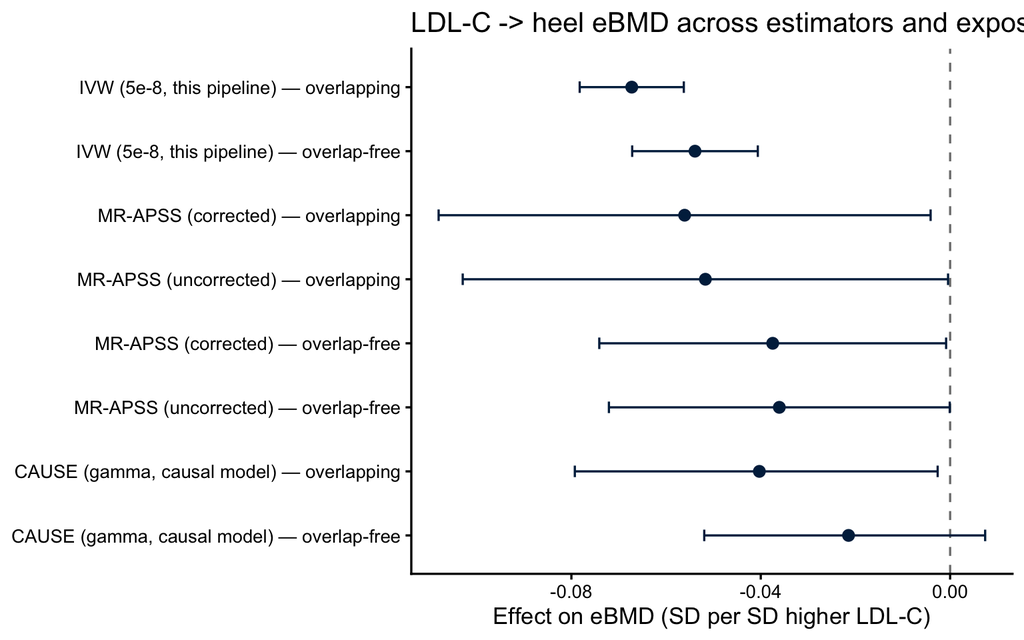

```r
if (nrow(combined) > 0) {
  robust_mr_forest(combined,
                   title = "LDL-C -> heel eBMD across estimators and exposure arms")
}
```

## 3. Reading the result grid

The four informative patterns, decided in advance so the interpretation is not chosen after seeing the numbers:

| MR-APSS | CAUSE | Reading |
| --- | --- | --- |
| $\beta<0$, significant | causal preferred | The strongest available support for a genuine cholesterol → BMD effect. Survives overlap, correlated pleiotropy, and winner’s curse. |
| $\beta<0$, significant | sharing not rejected | Effect is real *or* driven by a shared factor; CAUSE cannot separate them at this power. Report both; do not claim causality. |
| $\beta \approx 0$ | sharing not rejected | The conventional IVW estimate (−0.051) was substantially overlap- and/or pleiotropy-driven. This would be a material revision to `ANALYSIS.md` §3. |
| $\beta \approx 0$ | causal preferred | Unusual. Check the $C$ matrix — a large LDSC intercept inflates MR-APSS standard errors and can null out a real effect. |

Note that none of these bear on the **HMGCR cis** result (β ≈ −0.115). That is a drug-target design with a different identifying assumption, and it is not adjudicated by genome-wide polygenic methods. The relationship between the two is the interesting part: if genome-wide LDL → BMD collapses under CAUSE/MR-APSS while the HMGCR cis effect stands, that *strengthens* the paper’s central claim that the mechanism is mevalonate-specific rather than LDL-mediated.

## 4. Limitations to carry into the write-up

- **MRAID was not run.** It is a strict two-sample method and the primary design shares UK Biobank across exposure and outcome. It is deferred to a UK Biobank → MGI/BioVU design, mirroring the architecture already used for serum calcium.
- **Both methods assume the LDSC/polygenic model.** MR-APSS inherits LDSC’s assumptions directly; CAUSE assumes the shared factor acts on both traits through the same variants. Neither handles a *reverse* effect of BMD on lipids — run the reverse direction separately if that is in question.
- **European ancestry only.** `eur_w_ld_chr` and the 1000G EUR panel restrict this to the European subsets; the multi-ancestry power of GLGC 2021 is not used.
- **CAUSE is conservative by design.** A null CAUSE result is weak evidence of no effect, not strong evidence.
- **The eBMD outcome is heel quantitative ultrasound**, not DXA. The femoral-neck DXA result in `ANALYSIS.md` was null but underpowered (GEFOS n ≈ 33k), and that cohort is too small for LDSC-based methods.

## 5. Suggested text for ANALYSIS.md

[output not shown]